# Expected travel time delay and weather conditions

Maria Osipenko

2023-07-21

# 1 Introduction

Optimal departure time choice modeling comes frequently with the so called scheduling part, where the disutility or costs from early or late arrival weighted with preference parameters come into play, where vast majority of models builds upon an asymmetric linear scheduling part. (Fosgerau and Karlström (2010), Zhang and Homem-de-Mello (2017), Guo et al. (2017), Li (2019), Jin (2020)). That is, as in Fosgerau and Karlström (2010) in utility terms:

$$U_1(d,T) = -\{\alpha T + \beta(d-T)\mathbf 1_{T<d} + \gamma (T-d)\mathbf 1_{T\geq d}\},$$
where $T$ is random travel time with cumulative distribution function $F$, the preferred arrival time is normalized to $0$, and $-d$, $d>0$ is departure time. The optimal departure time has been shown to be equal to $d^* = \mu + \sigma F^{-1}\left(\frac{\gamma}{\beta+\gamma}\right)$ in Fosgerau and Karlström (2010). This type of utility comes with the assumption of strictly increasing cumulative distribution function $F$ of $T$, such that the inverse $F^{-1}\left(\frac{\gamma}{\beta+\gamma}\right)$ for all possible preference parametrizations $\beta$ and $\gamma$ exists. That is, this scheduling approach does not work in case of a pure discrete travel time distribution or a mixture with a discrete component as in Palma, Lindsey, and Picard (2012). Palma, Lindsey, and Picard (2012) model the travel time distribution as a mixture of a continuous part on bad days and a discrete component on good days. They use, therefore, the classical CARA and HARA utility specifications, which describe the scheduling choice less “authentically”.

In this paper, we propose an alternative specification of the scheduling part and define:
$$U_2(d,T) = -\{\alpha T + \beta(d-T)^2\mathbf 1_{T<d} + \gamma (T-d)^2\mathbf 1_{T\geq d}\}$$
with asymmetric *quadratic* loss on the delay. In this preferences formulation, the marginal disutility increases along with the delay magnitude, which may describe the preferences of at least some commuters in a more consistent way. In fact, this preference specification fulfill the assumptions of Smith (1984) and Daganzo (1985) for existense and uniqueness of equilibrium in a single bottleneck model. It also sattidfies the requirenment of Palma, Lindsey, and Picard (2012) and their equilibrium analysis with risk aversion and information value.

In this paper, we introduce the alternative asymmetric quadratic specification of scheduling preferences, show that the optimal departure times are quantiles for linear and expectiles for quadratic version of the utility, and demonstrate some advantages of the expectile version. We also show, that the asymmetric quadratic class of scheduling preference function is a richer one, than the linear asymmetric preferences, based on quantile-expectile correspondence. Finally, we propose appropriate measures for travel time variability based on tail indices.

# 2 Defining scheduling preferences

Fosgerau and Karlström (2010) uses the so call scheduling utility and derives the optimal departure time in a mean-variance framework. Li (2019) proposes a nonparametric approach to estimate the travel time reliability ratio using its connection to conditional value at risk. Zhang and Homem-de-Mello (2017) uses the same concept of penalties for late and early arrival to find an optimal travel path for risk averse travelers. The authors employ stochastic orders to choose between candidate routes. Jin (2020) use analogeously defined scheduling for their optimal departure choice problem.

Consider a planer with utility function depending on random travel time $T$ with realizations in $\mathbb R_+$ and on the departure time $-d$ for $d>0$ with the preferred arrival time normalized to $0$. According to the scheduling approach of Fosgerau and Karlström (2010):

$$U_1(d,T) = -\{\alpha T + \beta(d-T)\mathbf 1_{T<d} + \gamma (T-d)\mathbf 1_{T\geq d}\}$$

for $\gamma>\beta>0$ for an equilibrium state to be reached (K. Small (1982), K. A. Small (2015)).

In this formulation, both early and late arrival increase the disutility of the planer in a **linear** manner with the marginal disutility of early arrival being equal to $b$ and the marginal disutility of late arrival being equal to $\gamma$. Note, that the utility decrease is asymmetric regarding the type of delay (early or late).

The asymmetric linear loss may be unrealistic in many situations, because marginal disutility of early delays or late delays is constant and does not depend on the magnitude of the delay. Bogers et al. (2006) for instance find that extremly long travel times influence significantly route choice. When the marginal disutility increases along with the delay magnitude and an asymmetric **quadratic** loss would describe such preferences in a more consistent way. In fact, such specification of the planer utility function even simplifies the computation of the optimal departure time, as we show later. The asymmetric quadratic version of $U_1(d,T)$ reads:

$$U_2(d,T) = -\{\alpha T + \beta(d-T)^2\mathbf 1_{T<d} + \gamma (T-d)^2\mathbf 1_{T\geq d}\}$$

We assume, that planer maximizes her expected utility, which is in this case ($\mathbb E(\cdot)$ denotes the expectation with respect to the distribution function of $T$, $F$):

- **linear asymmetric case**

$$\mathbb EU_1(d,T) = -\left[\alpha \mathbb ET + \beta\mathbb E\left\{(d-T)\mathbf 1_{T<d} \right\}+ \gamma \mathbb E\left\{(T-d)\mathbf 1_{T\geq d}\right\}\right].$$

- **quadratic asymmetric case**

$$\mathbb EU_2(d,T) = -\left[\alpha \mathbb ET + \beta\mathbb E\left\{(d-T)^2\mathbf 1_{T<d} \right\}+ \gamma \mathbb E\left\{(T-d)^2\mathbf 1_{T\geq d}\right\}\right].$$
Both utility formulations fall under the mean-dispersion framework (Engelson and Fosgerau (2016)) with different notions of dispersion used. Note that for $\beta=\gamma$, $\mathbb EU_2(d,T)$ becomes
$$\mathbb EU_2(d,T) = -\left[\alpha \mathbb ET + \beta\mathbb E\left\{(T-d)^2\right\}\right],$$
which is maximized for $d^* = \mathbb ET$ and we recover the classical mean-variance utility $\mathbb EU^*_2(d^*,T)$ used by Jackson and Jucker (1982). For $\gamma>\beta$ the second term, as we show later, is generalized $\tau$-variance around a certain tail index - $\tau$-expectile. The later formulation of preferences in $U_2$ has the advantage of being differentiable with respect to $d$, which is a condition of uniqueness of the resulting equilibrium distribution of arrivals at a single bottleneck model (Daganzo (1985)). Moreover, both utility functions are reformulations of cost functions in departure time choice problems in single bottlenecks as in Lindsey (2004).

[output not shown]

# 3 Optimal departure times for a planer with $U_i(d,T), i \in\{1,2\}$

In this section, we show that the optimal departure time turns to be equal to a certain quantile (see Koenker and Bassett (1978)) in case of $U_1(d,T)$ and a certain expectile (see Newey and Powell (1987)) for $U_2(d,T)$ of the travel time distribution. The particular quantile or expectile levels depend on the asymmetry parameter ($\beta$ and $\gamma$) of planer’s utility function.

We, therefore briefly review the concepts of quantiles and expectiles in the following.

## 3.1 Quantiles and expectiles

Quantiles and expectiles are real numbers which describe a distribution of a real random variable $X$. They generalize the median and the mean respectively to their asymmetric versions via the asymmetry index $\tau\in(0,1)$. For a suitable set of such indices $\tau\in(0,1)$ the associated sets of either quantiles $\{q_\tau(X)\}_{\tau\in(0,1)}$ or expectiles $\{e_\tau(X)\}_{\tau\in(0,1)}$ are capable of representing the entire distribution of a random variable.

Both quantiles and expectiles can be viewed as minimizers of expectations of asymmetric norms (see e.g. Tran et al. (2019)):
$$\begin{align}
\min_{c\in\mathbb R}\mathbb E_{F_X}||X-c||^a_{a,\tau}, \text{ for } a\in\{1,2\}, \tag{3.1}
\end{align}$$
where $||x||^a_{a,\tau}=|x|^a\cdot\{\tau\mathbf 1_{x\geq 0}+(1-\tau)\mathbf 1_{x<0}\}$ is the asymmetric norm for $x\in\mathbb R$. That is, the $\tau$-quantile solves $q_\tau(X) = \arg\min_{q\in\mathbb R}\mathbb E_{F_X}||X-q||^1_{1,\tau}$ whereas the $\tau$-expectile solves $e_\tau(X) = \arg\min_{e\in\mathbb R}\mathbb E_{F_X}||X-e||^2_{2,\tau}$.

Expectiles are uniquely defined for random variables with finite expectations, whereas for quantiles to be unique, we need a strictly increasing cumulative distribution function $F$. This creates difficulties in treating e.g. discrete distributions as the following example shows.

**Example 3.1 (Quantiles and expectiles of a two-value travel time distribution)** Consider random travel time $T$ with two values: $t_1$ with probability $p$ and $t_2$, $t_2-t_1>0$ with probability $1-p$. For example, on a ideal road link without congestion two speed regimes hold depending on whether the road surface is wet or not (or there is fog or not). Then $1-p$ could be the probability of wet surface or the probability of rain.

Since $\mathbb P(T\leq t) = 0$ for $t\in(-\infty,t_1)$, for any $\tau\in (0,p]$ the $\tau$-quantile is any number in the range $[0,t)$. Likewise, since $\mathbb P(T\leq t) = p$ for $t\in[t_1,t_2)$ and for any $\tau \in(p,1)$ it is any number in the range $[t_1,t_2)$. It is unclear whether and how much the $\tau$-quantile is affected by a change in $p$.

In case of expectiles using formulas (18) and (19) in Holzmann and Klar (2015) we have:

$$e_\tau = \frac{(1-\tau)t_1p+ \tau t_2(1-p)}{(1-\tau)p + \tau(1-p)}$$
which is continuous and strictly increasing in $\tau$.

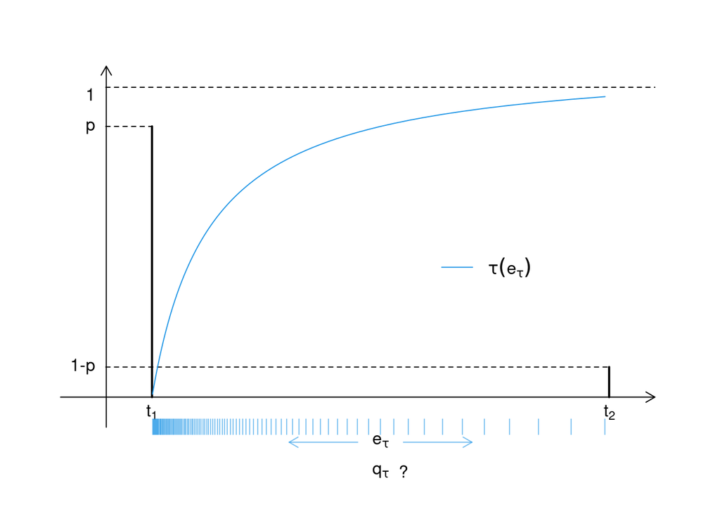

Since
$$\frac{\partial e_\tau}{\partial l} = \tau(1-p)>0$$
it is also an increasing function of $l$.

Note that since

$$\frac{\partial e_\tau}{\partial p} =(-l)\cdot \frac{ \tau (1-\tau)} {\{\tau+p (1-2\tau )\}^2} <0$$
$e_\tau$ decreases in $p$ or equivalent it increases in $1-p$.

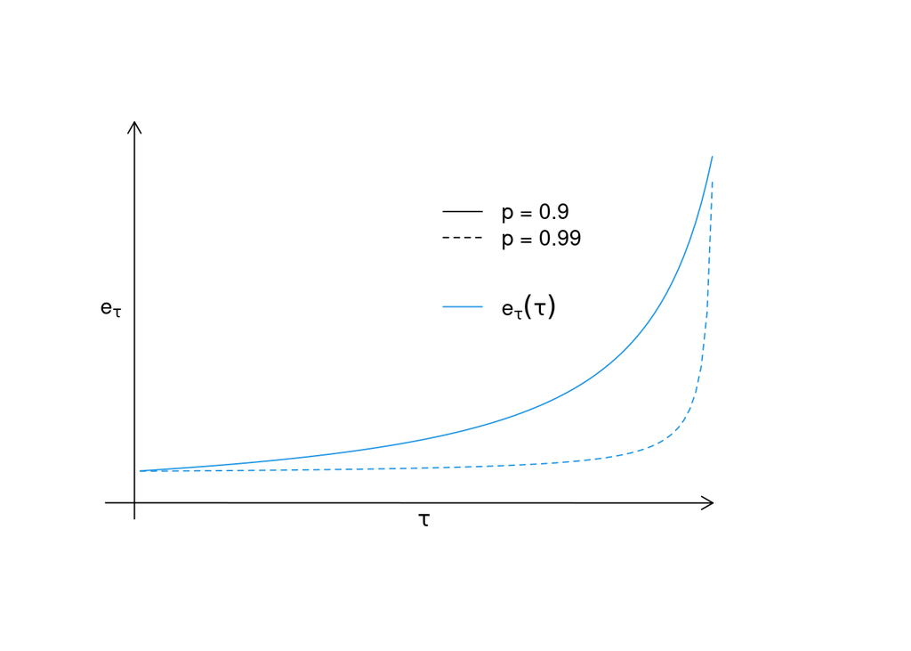

In the example above, we derive an explicit expression for $e_\tau$. However, this is not always possible and $e_\tau$ is represented in an implicit functional form based on the first order condition of (3.1) for $a=2$:

$$\begin{align}
\tau\mathbb E\{|Y-e_\tau|\mathbf 1_{Y>e_\tau}\} = (1-\tau)\mathbb E\{|Y-e_\tau|\mathbf 1_{Y\leq e_\tau}\}.\tag{3.2}
\end{align}$$

Moreover, as $e_\tau$ is continuous, strictly increasing in $\tau$, and unique for each $\tau\in(0,1)$ for all distributions $F$ with finite expectation (Holzmann and Klar (2015)), there exist an inverse expectile function $\tau(e_\tau)$ which frequently does have an explicit functional form, convenient for the analysis. In fact, the inverse expectile function is itself a cumulative distribution function with a density, but it differs in general from the original $F$ as Philipps (2022). Rearranging (3.2), we get the following expression for the inverse expectile function $\tau(\mu_\tau)$:

$$\begin{align}
\tau(e_\tau) &= \frac{\mathbb E\{|Y-e_\tau|\mathbf 1_{Y\leq e_\tau}\}} {\mathbb E\{|Y-e_\tau|\}} = \frac{\mathbb E\{(Y-e_\tau)\mathbf 1_{Y\leq e_\tau}\}}{2\mathbb E\{(Y-e_\tau)\mathbf 1_{Y\leq e_\tau}\} - \mathbb E\{(Y-e_\tau)\}} \tag{3.3}
\end{align}$$

**Example 3.2 (Quantiles and expectiles of a mixture of two uniform distribution with disjoint supports)** Consider another, perhaps, more realistic example. The random travel time $T$ follows a mixture of uniform distributions with ranges $[a_1,a_2]$ and $[a_3, a_4]$ respectively and with mixing probability $p$. We assume that $a_1<a_2<a_3<a_4$ such that there is a “gap” in the support of the mixture distribution. Again, we could consider a road link without congestion with two speed regimes depending on some exogenous event $I$ taking values $\{0,1\}$ with probability $p$ and $1-p$ respectively. We think of $p$ large and $1-p$ small.

Let $F$ denote the cumulative distribution function of $T$. The quantile function for $\tau <p$ is $q_\tau = a_1 + \frac{a_2-a_1} p\tau$ and for $p<\tau$ it is $q_\tau = a_3 + \frac{a_4-a_3}{1-p}(\tau-p)$. However, when $\tau=p$ any value on $(a_2,a_3)$ is a valid candidate for the $p$-quantile.

Starting with ((3.3)) we compute the inverse expectile function $\tau(e_\tau)$ as:

$$\tau(e_\tau)=\begin{cases}
0, &e_\tau<a_1\\
\frac{-\frac 12 \frac{p}{a_2-a_1}(a_1-e_\tau)^2}{-\frac{p}{a_2-a_1}(a_1-e_\tau)^2 -(\frac{p(a_1+a_2)}2 + \frac{(1-p)(a_3+a_4)}2 - e_\tau)}, & a_1\leq e_\tau<a_2,\\
\frac{p\left(\frac{a_1 + a_2}2 - e_\tau\right)}{2p\left(\frac{a_1 + a_2}2 - e_\tau\right) -(\frac{p(a_1+a_2)}2 + \frac{(1-p)(a_3+a_4)}2 - e_\tau)}, & a_2\leq e_\tau<a_3,\\
\frac{p\left(\frac{a_1 + a_2}2 - e_\tau\right)-\frac 12 \frac{1-p}{a_4-a_3}(a_3-e_\tau)^2}{2p\left(\frac{a_1 + a_2}2 - e_\tau\right)-\frac{1-p}{a_4-a_3}(a_3-e_\tau)^2 -(\frac{p(a_1+a_2)}2 + \frac{(1-p)(a_3+a_4)}2 - e_\tau)}, & a_3\leq e_\tau<a_4,\\
1, &e_\tau\geq a_4.
\end{cases}$$

The resulting expectile functions as functions of $\tau$ for different $p$ are presented in Figure

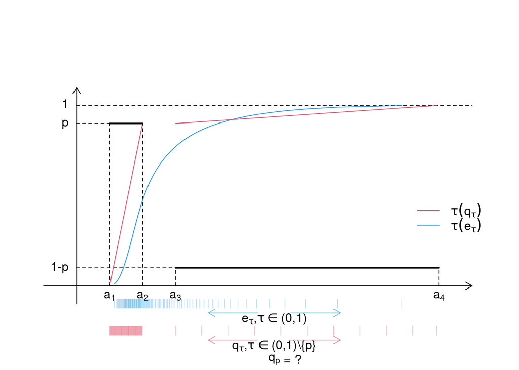

Figure 3.1: Quantile and expectile functions for the mixture of two uniform distributions.

The next Figure illustrated the change when $p$ changes

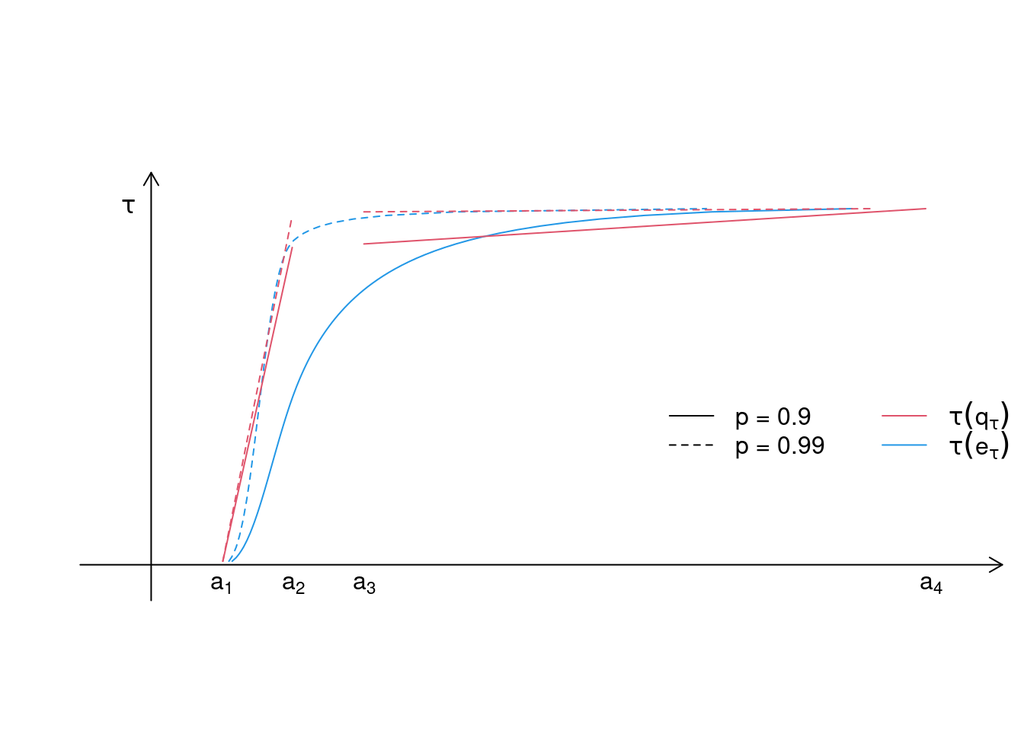

Figure 3.2: Quantile and expectile functions for two scenarios of mixing parameter p in the mixture of two uniform distributions.

For mixtures of $m$ disjoint (sorted) uniforms holds with mixing parameter vector $\mathbf p=(p_1,\ldots,p_m)^\top$ where $p_m=1-\sum_{i=1}^{m-1}p_i$ and support edges $a_1<a_2<\ldots<a_{m+1}$:

$$\tau(e_\tau) =
\begin{cases}
0,&e_\tau<a_1,\\
\frac{-\frac 12\frac{p_1}{a_2-a_1}(a_1-e_\tau)^2} {-\frac{p_1}{a_2-a_1}(a_1-e_\tau)^2- \sum_{j=1}^mp_j\frac{a_{j+1}+a_j}2 +e_\tau} ,&a_1\leq e_\tau< a_2,\\
\frac{\frac 12\sum_{k=1}^{i-1}p_k\cdot (a_{k+1}+a_{k}-2e_\tau) -\frac 12 \cdot \frac{p_i}{a_{i+1}-a_i}(a_i-e_\tau)^2} {\sum_{k=1}^{i-1}p_k\cdot (a_{k+1}+a_{k}-2e_\tau) -\frac{p_i}{a_{i+1}-a_i}(a_i-e_\tau)^2- \sum_{j=1}^mp_j\frac{a_{j+1}+a_j}2 +e_\tau} ,&a_i\leq e_\tau< a_{i+1},i=2,\ldots, m\\
1, &e_\tau\geq a_{m+1}.
\end{cases}$$

The derivations hereof are shown in the Appendix.

The problematic in Example 3.2 translates readily to the urban arterial roads travel times model of Zheng, Zuylen, and Liu (2017), where for the oversaturated condition, the probability function of delay consists of several box shaped functions with bounded support, which may (or may not) overlap. The authors distinguish two regimes: undersaturated and oversaturated conditions. The resulting delay distribution is composed of a mixture of Dirac delta function on fixed free-flow time (or a countinous distribution of free-flow time) and several uniform delay distributions with bounded support representing the effects of traffic lights, traffic control or similar conditions.

In this case the quantiles are well defined for $i=1,\ldots, m$ and $\tau\in(p_0,1)\setminus\{p_1,\ldots,p_m\}$ as:

$$q_\tau = a_{i} + \frac{a_{i+1}-a_{i}}{p_i}(\tau-\sum_{k=1}^{i-1}p_{k} - p_0), p_i<\tau<p_{i+1}.$$

The inverse expectile function is:

$$\tau(e_\tau) =
\begin{cases}
0,&e_\tau<a_0,\\
(a_0-e_\tau)p_0,&a_0\leq e_\tau<a_1,\\
\frac{(a_0-e_\tau)p_0-\frac 12\frac{p_1}{a_2-a_1}(a_1-e_\tau)^2} {(a_0-e_\tau)p_0-\frac{p_1}{a_2-a_1}(a_1-e_\tau)^2- \sum_{j=1}^mp_j\frac{a_{j+1}+a_j}2 +e_\tau} ,&a_1\leq e_\tau< a_2,\\
\frac{(a_0-e_\tau)p_0+\frac 12\sum_{k=1}^{i-1}p_k\cdot (a_{k+1}+a_{k}-2e_\tau) -\frac 12 \cdot \frac{p_i}{a_{i+1}-a_i}(a_i-e_\tau)^2} {(a_0-e_\tau)p_0+\sum_{k=1}^{i-1}p_k\cdot (a_{k+1}+a_{k}-2e_\tau) -\frac{p_i}{a_{i+1}-a_i}(a_i-e_\tau)^2- \sum_{j=1}^mp_j\frac{a_{j+1}+a_j}2 +e_\tau} ,&a_i\leq e_\tau< a_{i+1},i=2,\ldots, m\\
1, &e_\tau\geq a_{m+1}.
\end{cases}$$

See Appendix for the deriviation.

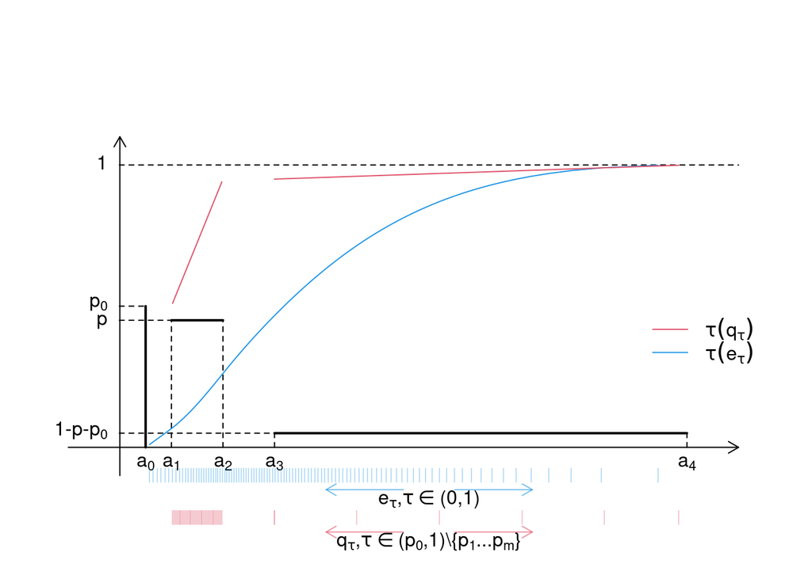

Figure 3.3: Quantile and expectile functions for the mixture of a point mass and two uniform distributions.

In this example, we have a bunch of $\tau$-values, for which quantiles are not well defined. On the other hand, expectiles are still capable of capturing these kind of distributions.

As also explored in Zheng, Zuylen, and Liu (2017), the point mass at $a_0$ can be substituted by a distribution centered at $a_0$, since different vehicle or driver types may exhibit slightly varying free-flow times.

Note that instead of uniform mixture components, one can use more general forms offered for bounded supports e.g. by four parameter beta distributions also used in Jabari, Freris, and Dilip (2020) for travel times modelling. In this case the form of $\tau(e_\tau)$ becomes more complicated, however numeric computation based on Equation (3.3) is still feasible/possible.

Being quantile-alike tail indices, expectiles share some properties of quantiles, as location and scale equivariance.

**Proposition 3.1 (Location and scale equivariance of quantiles and expectiles)** Let $Y\in\mathbb R$ be a random variable with finite expectation, then for $\tau \in (0,1)$ and $s>0$

- $q_\tau(sY+m) = sq_\tau(Y) + m$ (follows from location and scale equivariance of the quantile loss function) and
- $e_\tau(sY+m)=se_\tau(Y) + m$ (Theorem 1 in Newey and Powell (1987)).

with $\tau=\frac{\gamma}{\gamma+\beta}.$

These properties are also useful for analysing the role of travel time mean and variance for optimal departure time plans.

Another useful property is the existence of the correspondence between (well defined) quantiles and expectiles (see Jones (1994), Yao and Tong (1996) and Waltrup et al. (2015)) of a distribution.

**Proposition 3.2 (Quantile-expectile correspondence)** For each well defined $\tau_1$-quantile, there exist $\tau_2(\tau_1)\in(0,1)$, such that $q_{\tau_1}(Y) = e_{\tau_2(\tau_1)}(Y).$ The correspondence function between quantile and expectiles of a random Variable $T\in \mathbb R$ with distribution function $F$, $\tau_2(\tau_1):(0,1)\rightarrow(0,1)$ is:
$$\tau_2 (\tau_1) = \frac{-q_{\tau_1}\tau_1 + G(q_{\tau_1})}{-\mathbb EY + 2G(q_{\tau_1})+q_{\tau_1}(1-2\tau_1)},$$
where $G(q) = \int_{-\infty}^qt~dF(t)$ is the partial moment function.

*Proof*. For any distribution $F$ with finite mean, the expectile function $\tau_2\rightarrow e_{\tau_2}(F)$ is continuos, stricktly increasing and has range $\{y\in\mathbb R: 0<F(y)<1\}$. So for each well defined quantile $q_{\tau_1}=F^{-1}(\tau_1)$ there exists $\tau_2$ such that
$$q_{\tau_1}(F) = e_{\tau_2}(F).$$

Following Yao and Tong (1996) and using the following identity for $\tau_2$:
$$\tau_2 = \frac{\mathbb E(|Y-e_{\tau_2}|\mathbf 1_{Y\leq e_{\tau_2}})}{\mathbb E(|Y-e_{\tau_2}|\mathbf 1_{Y\leq e_{\tau_2}}) + \mathbb E(|Y-e_{\tau_2}|\mathbf 1_{Y> e_{\tau_2}})},$$

we get
$$\tau_2 (\tau_1) = \frac{\mathbb E(|Y-q_{\tau_1}|\mathbf 1_{Y\leq q_{\tau_1}})}{\mathbb E(|Y-q_{\tau_1}|\mathbf 1_{Y\leq q_{\tau_1}}) + \mathbb E(|Y-q_{\tau_1}|\mathbf 1_{Y> q_{\tau_1}})}=$$

$$= \frac{-\mathbb E(Y\mathbf 1_{Y\leq q_{\tau_1}})+q_{\tau_1}\tau_1}{\mathbb E(Y\mathbf 1_{Y\leq q_{\tau_1}})-q_{\tau_1}\tau_1 + \mathbb E(Y\mathbf 1_{Y> q_{\tau_1}})-q_{\tau_1}(1-\tau_1)}=$$

$$= \frac{-\mathbb E(Y\mathbf 1_{Y\leq q_{\tau_1}})+q_{\tau_1}\tau_1}{\mathbb EY - 2\mathbb E(Y\mathbf 1_{Y\leq q_{\tau_1}})-q_{\tau_1}(1-2\tau_1)}.$$

Rewriting $\mathbb E(Y\mathbf 1_{Y\leq q}) = G(q)$, we obtain

$$\tau_2 (\tau_1) = \frac{-q_{\tau_1}\tau_1 + G(q_{\tau_1})}{-\mathbb EY + 2G(q_{\tau_1})+q_{\tau_1}(1-2\tau_1)}.$$

Using this correspondence between quantiles and expectiles, a comparison of the optimal plans for the two parameterizations of the utility function are straight forward.

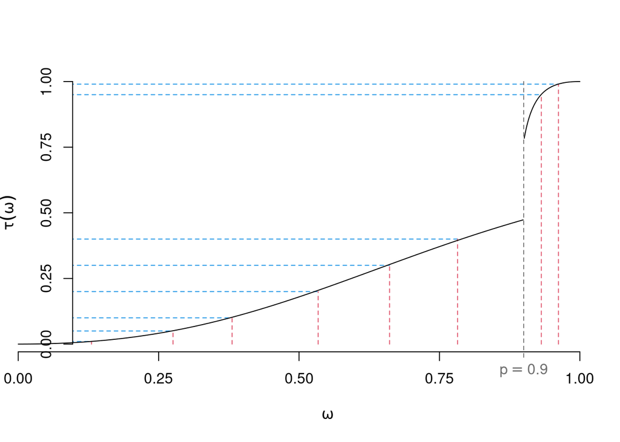

Figure 3.4: Quantile- expectile correspondence function for mixture of two uniform distributions.

The sample counterparts, $\hat q_\tau(X)$ and $\hat e_\tau(X)$, of the population $\tau$-quantile and $\tau$-expectile are computed as plug-in estimators based on the empirical distribution function:

$$\begin{align}
\hat q_\tau(X) = \arg\min_{q\in\mathbb R}\sum_{i=1}^n||x_i-q||^1_{1,\tau}, \tag{3.4}
\end{align}$$
and

$$\begin{align}
\hat e_\tau(X) = \arg\min_{e\in\mathbb R}\sum_{i=1}^n||x_i-e||^2_{2,\tau}. \tag{3.5}
\end{align}$$

In this formulation, both are asymmetric versions of M-estimators, M-quantiles, and with the corresponding properties as consistency and under some more restrictive assumptions as finite second moment and continuous $F$, asymptotic normality (Holzmann and Klar (2015), Abdous and Rémillard (1995), Breckling and Chambers (1988)). Moreover, as Abdous and Rémillard (1995), sample expectile estimators are more efficient than sample quantiles.

An estimate for the correspondence function can be obtained following the procedure of Taylor (2008), who construct an empirical cumulative distribution function by counting the observations below the estimated expectile for each of the $\tau$-levels, such that for each $\tau$ there is a corresponding estimate of quantile index $\omega$. One can then interpolate linearly between the resulting points to obtain $\hat\tau(\omega)$.

**Example 3.5 (Sample quantiles and expectiles)** Consider a (ordered) sample of the ten travel times:

$$10.42, 12.46, 13.28, 14.53, 15.73, 16.78, 19, 19.55, 19.57, 101.16$$

generated from a mixture of two uniform distributions with mixing parameter $p=0.9$ as well as $a_1=10$, $b_1=20$, $a_2=30$, and $b_2=110$.

For $\tau \in\{0.1, 0.25, 0.5, 0.75, 0.9\}$

- the sample quantiles are:
  $$\hat q_{0.1}=12.2568, \hat q_{0.25}=13.5927,\hat q_{0.5}=16.251,\hat q_{0.75}=19.4083,\hat q_{0.9}=27.7278$$
- the sample expectiles are:
  $$\hat e_{0.1}=15.4291, \hat e_{0.25}=18.5847,\hat e_{0.5}=24.2471,\hat e_{0.75}=37.0664,\hat e_{0.9}=58.432$$

## 3.2 Quantiles and expectiles of travel time distribution as maximizers of $U_1(d,T)$ and $U_2(d,T)$

Now, we come back to our planer’s utility function in the asymmetric linear and quadratic versions.

The following proposition connects the optimal departure times to quantiles and expectiles of travel time distribution.

**Proposition 3.3 (Optimal departure time plans)** Let $U_a(d,T), a\in\{1,2\}$ be planers utility function with $\beta_a>0$ and $\gamma_a>0$ fixed. Let $T$ be random travel time with distribution function $F$. Then, optimal departure time $d^*$ corresponds to:

- the $\tau_1$-quantile $q_{\tau_1}(T)$ of $F$ in case of $U_1(d,T)$
- the $\tau_2$-expectile $e_{\tau_2}(T)$ of $F$ in case of $U_2(d,T)$

with $\tau_a=\frac{\gamma_a}{\gamma_a+\beta_a}$ and $a\in\{1,2\}$. Alternatively, we can express the ratio $\frac{\gamma_a}{\beta_a}$ in terms of $\tau_a$ as
$$\frac{\gamma_a}{\beta_a} = \frac{\tau_a}{1-\tau_a}.$$

*Proof*. Rewrite $\mathbb EU_a(d,T)$ as
$$\mathbb EU_a(d,T) = -\left[\alpha_a \mathbb E(T^a) + (\gamma_a+\beta_a)\mathbb E\left\{\frac{\beta_a}{\gamma_a+\beta_a}(d-T)^a\mathbf 1_{T<d}+ \frac{\gamma_a}{\gamma_a+\beta_a}(T-d)^a\mathbf 1_{T\geq d}\right\}\right]$$

Setting $\tau_a=\frac{\gamma_a}{\gamma_a+\beta_a}$ we get

$$\begin{align}
\mathbb EU_a(d,T) &= -\left[\alpha_a \mathbb E(T^a) + (\gamma_a+\beta_a)\mathbb E\left\{(1-\tau_a)(d-T)^a\mathbf 1_{T<d}+ \tau_a(T-d)^a\mathbf 1_{T\geq d}\right\}\right]\\
&= -\left(\alpha_a \mathbb E(T^a) + (\gamma_a+\beta_a)\mathbb E\left[|T-d|^a\{(1-\tau_a)\mathbf 1_{T<d}+ \tau_a\mathbf 1_{T\geq d}\right\}\right)\\
&= -\alpha_a \mathbb E(T^a) - (\gamma_a+\beta_a)\mathbb E||T-d||_{a,\tau_a}^a.
\end{align}$$

That is, maximizing $\mathbb EU_a(d,T)$ over $d\in\mathbb R$ is equivalent to minimizing $\mathbb E||T-d||_{a,\tau_a}^a$ which gives $q_{\tau_1}(T)$ in case $a=1$ and $e_{\tau_2}(T)$ in case $a=2$.

Using the location scale invariance of quantiles in Proposition 3.1 in case of $a=1$, we get the well known result of Fosgerau and Karlström (2010), where the optimal departure time $d_1^* = \mu + \sigma F^{-1}\left(\frac{\gamma_1}{\beta_1+\gamma_1}\right)$ with $F$ being the cumulative distribution function of the standardized travel time.

The result for $a=2$ is new. Proposition 3.3 generalizes therefore the result of Fosgerau and Karlström (2010) to $a\in\{1,2\}$. Proposition 3.1 provides a better understanding how the considered type of utility function is linked to the distributional properties of travel time $T$. As there exist the correspondence function between quantiles and expectiles of a given distribution and each well defined quantile $q_{\alpha}(T)$ is represented by an expectile $e_{\tau(\alpha)}(T)$, and thus both utilities produce the same choices for suitably chosen preference parameter, see proposition 3.4. Moreover, the second asymmetric quadratic preference class is much richer than the first one as it delivers well defined solutions for every combination of sceduling preferences $\frac{\gamma_2}{\beta_2}$ not only for distributions of $T$ with strictly increasing $F$ but also for discrete distributions or distribution with discontinuous support (see examples 3.1 and 3.2).

**Proposition 3.4 (Correspondence between (U_1)- and (U_2)-based choices)** Let $U_1(d,T)$ be planers utility function with known $\gamma_1>\beta_1>0$. Let $T$ be random travel time with distribution function $F$ and finite mean. Then, for each $\tau_1 = \frac{\gamma_1}{\beta_1+\gamma_1}$, in which $F$ is invertible, there exist $\tau_2$ and $\gamma_2>\beta_2>0$ such that maximizing $\mathbb E U_1(d,T)$ with respect to $d$ is equivalent to maximizing $\mathbb E U_2(d,T)$ with respect to $d$ and thus both utilities represent the same scheduling preferences as they produce the same choices in the expected utility sense.

*Proof*. From 3.3 the optimal departure plan $d_1^*$ for $U_1(d,T)$ sattisfies:

$$d_1^* = \arg\min_{d\in \mathbb R^+}\mathbb E\left(||T-d||_{1,\tau_1}\right),$$

which matches with the $\tau_1$-quantile of travel time $T$ with $\tau_1=\frac{\gamma_1}{\beta_1+\gamma_1}$. Wenn $F$ is invertible in $\tau_1$, there exist a map $\tau_2\equiv\tau_2(\tau_1)$ such that for the $\tau_2$-expectile, $e_{\tau_2}$, holds $e_{\tau_2} = q_{\tau_1}$. That is,

$$d_1^* = \arg\min_{d\in \mathbb R^+}\mathbb E\left(||T-d||_{1,\tau_1}\right) = \arg\min_{d\in \mathbb R^+}\mathbb E\left(||T-d||_{2,\tau_2}^2\right) = d_2^*.$$

The parameter $\gamma_2>\beta_2>0$ are related as:

$$\frac{\gamma_2}{\beta_2+\gamma_2} = \tau_2(\tau_1) = \tau_2\left(\frac{\gamma_1}{\beta_1+\gamma_1}\right),$$

or $\frac{\gamma_2}{\beta_2} = \frac{\tau_2}{1-\tau_2},$ where $\tau_2\equiv \tau_2\left(\frac{\gamma_1}{\beta_1+\gamma_1}\right)$ is the quantile-expectile correspondence relation.

Comming back to our example with a sample of 10 travel times, we can now compute the optimal departure time points.

Table 3.1: Optimal $d^*$ for $U_1(d,T)$ and $U_2(d,T)$ based on the sample of the ten travel times: 10.42, 12.46, 13.28, 14.53, 15.73, 16.78, 19, 19.55, 19.57, 101.16.

[output not shown]

Note also, what happens with the optimal departure plans, if we add another extreme travel time observation 87.67 to our sample.

|  | $\frac{\beta}{\gamma}=1$ | $\frac{\beta}{\gamma}=2$ | $\frac{\beta}{\gamma}=3$ | $\frac{\beta}{\gamma}=4$ | =9 | =20 | =50 | =100 |
| --- | --- | --- | --- | --- | --- | --- | --- | --- |
| $d^*$ for $U_1(d,t)$ | 16.78 | 19.36 | 19.56 | 19.57 | 87.67 | 94.74 | 98.52 | 99.83 |
| $d^*$ for $U_2(d,t)$ | 30.01 | 39.92 | 47.19 | 52.74 | 68.18 | 79.96 | 88.12 | 94.05 |

## 3.3 Quantifying travel time variability with expectiles and quantiles

Zang et al. (2022) gives a comprehensive overview of reliability measures for travel time.

Regarding the utility linked value of travel time reliability, the travel time reliability ratio (TTRR), denoted here as $\rho_a$, which relates the value of travel time variability and to the value of travel time, seems to be the most commonly used measure in the literature (see Zang et al. (2022) and the references therein). Formally:

$$\begin{align}
\rho_a = \frac{d\mathbb EU_a^*}{d\sigma_T}/\frac{d\mathbb EU_a^*}{d\mu_T},
\tag{3.6}
\end{align}$$

where $\mu_T$ and $\sigma_T$ refer to the mean and the standard deviation of $T$.

Based on the results of Fosgerau and Karlström (2010) where

$$\begin{align}
\rho_1 = \frac{d\mathbb EU_1^*}{d\sigma_T}/\frac{d\mathbb EU_1^*}{d\mu_T} = \frac{\beta+\gamma}{\alpha}\int_{\frac{\gamma}{\beta+\gamma}}^1 F^{-1}(p)dp,
\tag{3.7}
\end{align}$$

Li (2019) propose a procedure to compute (3.7) based on the conditional value at risk. Here we derive the expressions for $\rho_a$ based on our notion of $\mathbb EU_a(d,T)$ and propose an estimation procedure based on empirical partial moments.

**Proposition 3.5 (Travel time reliability ratio)** Let $U_a(d,T), a\in\{1,2\}$ be planers utility function with $\beta>0$ and $\gamma>0$ known. Let $T$ be random travel time with distribution function $F$ with finite mean $\mu_T$ and finite variance $\sigma_T^2$. Then, the travel time reliabilty ratio $\rho_a$ is determined as:

$$\rho_a = \frac{a(\gamma+\beta)}{\alpha}\sigma_T^{a-1}\mathbb E||T_S-h_{a,\tau}(T_S)||_{a,\tau}^a,$$

with $h_{a,\tau^*} = \begin{cases} q_\tau^*(T),&\text{for } a=1,\\ e_\tau^*(T),&\text{for }a=2.\end{cases}$ and $\tau^* = \frac{\gamma}{\beta+\gamma}$.

*Proof*. Since $\mathbb E(T^2) = \sigma_T^2 + \mu_T^2$, we can rerwrite $\mathbb E(T^a) = \mu_T^{a} + (\sigma_T^2)^{a-1}$ and
$$\mathbb E U_a^*(d,T) =-\alpha (\mu_T^{a} + (\sigma_T^2)^{a-1}) - (\gamma+\beta)\mathbb E||T-h_{a,\tau^*}(T)||_{a,\tau^*}^a\\
=-\alpha (\mu_T^{a} + (\sigma_T^2)^{a-1})- (\gamma+\beta)\sigma_T^a\mathbb E||T_S-h_{a,\tau^*}(T_S)||_{a,\tau^*}^a$$

The last line based on the scale variance of expectiles and

$$\mathbb E||T-h_{a,\tau^*}(T)||_{a,\tau^*}^a=\mathbb E||(\sigma_TT_S + \mu_T)-(\sigma_Th_{a,\tau^*}(T_S)+\mu_T)||_{a,\tau^*}^a \\
= \mathbb E||\sigma_T(T_S-h_{a,\tau^*}(T_S))||_{a,\tau^*}^a = \sigma_T^a\mathbb E||T_S-h_{a,\tau^*}(T_S)||_{a,\tau^*}^a,$$

where $T_S$ denotes the standardized version of $T$.

The travel time reliability ratio is:

$$\rho_a=\frac{d\mathbb EU_a^*}{d\sigma_T}/\frac{d\mathbb EU_a^*}{d\mu_T}$$

The value of travel time is:

$$\frac{d\mathbb EU_a^*}{d\mu_T} = -a\alpha \mu_T^{a-1}$$

The value of travel time variability is:

$$\frac{d\mathbb EU_a^*}{d\sigma_T} = -a(\gamma+\beta)\sigma_T^{a-1}\mathbb E||T_S-h_{a,\tau}(T_S)||_{a,\tau}^a$$

Thus,

$$\rho_a=\frac{a(\gamma+\beta)}{\alpha}\sigma_T^{a-1}\mathbb E||T_S-h_{a,\tau}(T_S)||_{a,\tau}^a$$
.

and thus, explicitly depends on standard deviation of $T$. The terms $\mathbb E||T_S-q_{\tau^*}(T_S)||_{1,\tau^*}$ and $\mathbb E||T_S-e_{\tau^*}(T_S)||_{2,\tau^*}^2$ represent respectively the asymmetrically weighted absolute deviation and the asymmetrically weighted variance of $T$, which Tran et al. (2019) call $\tau$-deviation ($Dev_\tau(T)$) and $\tau$-variance ($Var_\tau(T)$). Both can be obtained in practice using their empirical counterparts:

$$\widehat{Dev_\tau} (T) = \frac 1n\sum_{i=1}^n |\tau^*- \mathbf 1_{t_{S,i}\leq q_{\tau^*}}|\cdot|t_{S,i}-\hat q_{\tau^*}|$$
and

$$\widehat{Var_\tau} (T) = \frac 1n\sum_{i=1}^n |\tau^*- \mathbf 1_{t_{S,i}\leq q_{\tau^*}}|\cdot |t_{S,i}-\hat q_{\tau^*}|^2$$
which are both readily calculated from sampled of travel times.

# 4 Real-data example

We provide a real data example using the dataset of travel times for Montreal.

## 4.1 Data and preprocessing

For our real data example, we fit a three component beta mixture to travel times on link with ID 174, measured in February 2019 in Montreal. We take the subset of travel times recorded between 6:00 and 7:00 am on regular working days Monday through Thursday. The reason for choosing February is the frequency of extreme weather events, which contribute to extreme travel times. Indeed, the data seem to have three regimes, which we model with a three component mixture of four-parameter beta distributions.

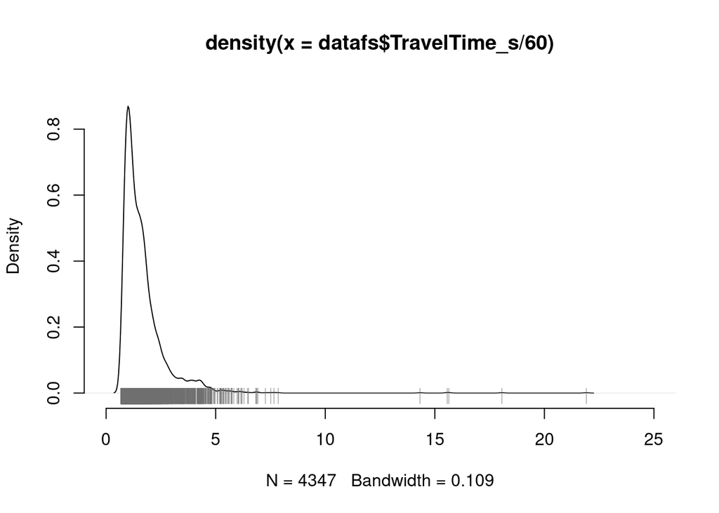

## 4.3 Comparing optimal departure time choices for $U_1(T,d)$ and $U_2(T,d)$

```
## [1] 140
```

Table 4.1: The estimated parameters of the three component beta mixtures.

|  | probability | shape 1 | shape 2 | lower | upper |
| --- | --- | --- | --- | --- | --- |
| component 1 | 0.775 | 0.88 | 1.33 | 0.58 | 2.01 |
| component 2 | 0.224 | 0.74 | 6.15 | 1.99 | 11.00 |
| component 3 | 0.001 | 0.65 | 3.04 | 14.07 | 31.16 |

Note, that there is a gap in the support of the estimated mixture between second and third component on the interval $(11,14.07)$. That is, for the $\tau$-value equal to the cumulative probability of the first two components, there will be no unique value.

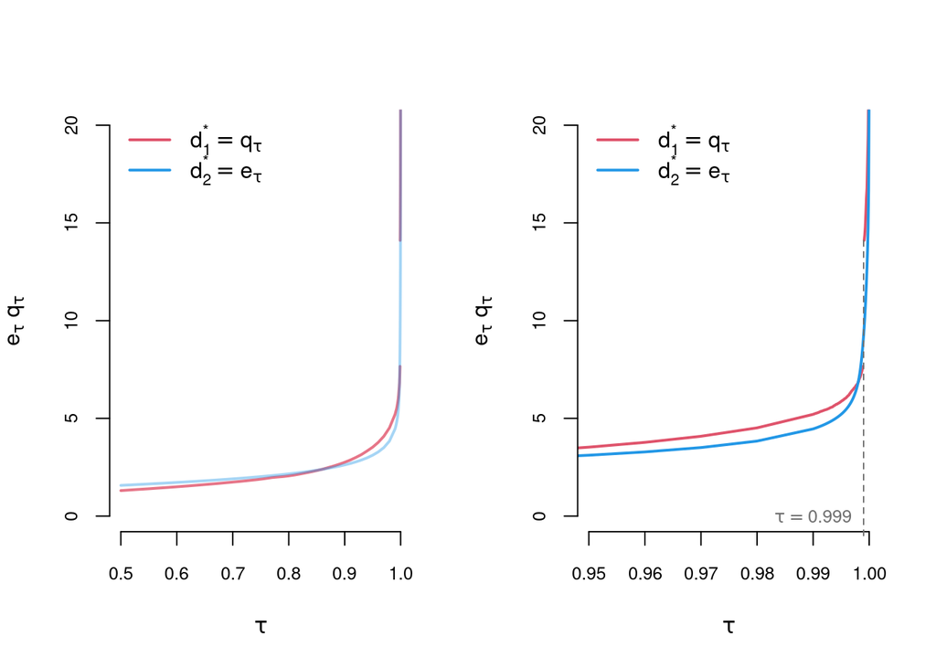

Hence, for this real data example, the optimal departure plan for a planer with $U_1$ and preference parameters which yield $\tau=0.999$, no unique solution can be found as any value on the interval $(11,14.07)$ is admissible. Whereas, for a planer with $U_2$ the choice is unique, no matter which preference parameters she has.

In this example, we have the following quantile-expectile correspondence $\tau_2(\tau_1)$ for $\tau_1\in(0.5,1)$ with a “hole” at $\tau_1=0.999$ which is show in Figure .

```
## [1] 150
```

Finally, the variability measures and the TTRRs as functions of $\tau$ are plotted in Figure .

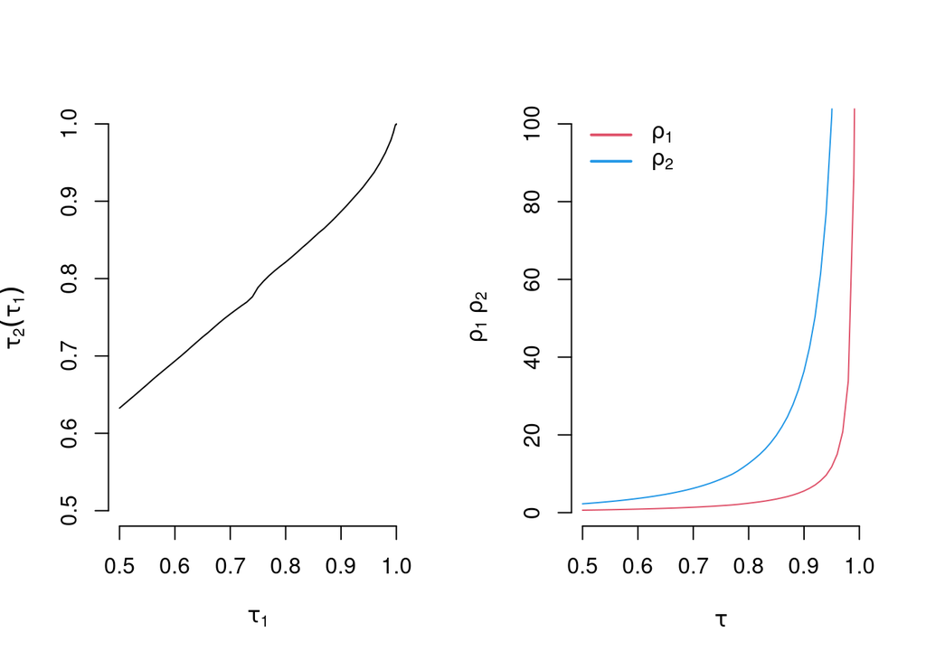

As seen, the value of travel time reliability associated with $U_2$ is always higher than that of $U_1$.

# 5 Conclusion

In this paper, we considered a classical specification of scheduling utility as asymmetric linear function of delays along with a new alternative specification based on asymmetric quadratic loss. We showed that the optimal departure choices for both utilities are tail indices of travel time distribution. Specifically, for the asymmetric linear specification those are certain quantiles and for the asymmetric quadratic specification, expectiles, of the travel time. Moreover, we demonstrated that there exists a correspondence of choices based on our alternative specification to the choices made according to the classical one in case of invertible cumulative distribution function. Finally, we show that our asymmetric quadratic preference formulation is a richer one, since unique optimum is obtained for any distribution of travel time with finite mean.

# 6 Appendix

## 6.1 Deriviations in Example 3.2

For a mixure of $m$ nonoverlapping uniforms (disjoint supports) with mixing parameter vector $\mathbf p=(p_1,\ldots,p_m)^\top$ where $p_m=1-\sum_{i=1}^{m-1}p_i$ and support edges $a_1<a_2<\ldots<a_m$:
$$f(y)=\sum_{j=1}^m\frac{p_j}{a_{j+1}-a_j}\mathbf 1_{y\in [a_j,a_{j+1}]}.$$

The inverse expectile function is defined as:

$$\tau(e_\tau) = \frac{\mathbb E\{(Y-e_\tau)\mathbf 1_{Y\leq e_\tau}\}} {2\mathbb E\{(Y-e_\tau)\mathbf 1_{Y\leq e_\tau}\} - \mathbb E\{(Y-e_\tau)\}}$$

For $\mathbb E\{(Y-e_\tau)\mathbf 1_{Y\leq e_\tau}\}$ we have:

- for $a_1\leq e_\tau< a_2$

$$\mathbb E\{(Y-e_\tau)\mathbf 1_{Y\leq e_\tau}\} = \int_{a_1}^{e_\tau}(y-e_\tau)\frac{p_1}{a_2-a_1}dy = \frac{p_1}{a_2-a_1}\int_{a_1}^{e_\tau}(y-e_\tau)dy$$

$$= \frac{p_1}{a_2-a_1}\frac 12[(y-e_\tau)^2]_{a_1}^{e_\tau} = -\frac{p_1}{a_2-a_1}\frac 12 (a_1-e_\tau)^2$$

- for $a_2\leq e_\tau< a_3$

$$\mathbb E\{(Y-e_\tau)\mathbf 1_{Y\leq e_\tau}\} = \int_{a_1}^{a_2}(y-e_\tau)\frac{p_1}{a_2-a_1}dy + \int_{a_2}^{e_\tau}(y-e_\tau)\frac{p_2}{a_3-a_2}dy$$

$$= \frac{p_1}{a_2-a_1}\frac 12[(y-e_\tau)^2]_{a_1}^{a_2} + \frac{p_2}{a_3-a_2}\frac 12[(y-e_\tau)^2]_{a_2}^{e_\tau} =\frac{p_1}2\cdot (a_2+a_1-2e_\tau) -\frac{p_2}{a_3-a_2}\frac 12 (a_2-e_\tau)^2$$

- for $a_i\leq e_\tau< a_{i+1}, 1<i\leq m$

$$\mathbb E\{(Y-e_\tau)\mathbf 1_{Y\leq e_\tau}\} =\int_{a_1}^{a_{i}}(y-e_\tau)f(y)dy + \int_{a_i}^{e_\tau}(y-e_\tau)f(y)dy$$
$$=\sum_{k=1}^{i-1}\frac{p_k}{a_{k+1}-a_k}\int_{a_k}^{a_{k+1}}(y-e_\tau)dy + \frac{p_i}{a_{i+1}-a_i} \int_{a_i}^{e_\tau}(y-e_\tau)dy$$

$$=\frac 12\sum_{k=1}^{i-1}p_k\cdot (a_{k+1}+a_{k}-2e_\tau) -\frac 12 \cdot \frac{p_i}{a_{i+1}-a_i}(a_i-e_\tau)^2 =\left(\sum_{k=1}^{i-1}{p_k}\frac{a_{k+1}+a_{k}}2-p_ke_\tau\right) -\frac 12 \cdot \frac{p_i}{a_{i+1}-a_i}(a_i-e_\tau)^2 .$$
In the expression above, the first term represents the weighted mean-expectile difference of mixture components with supports below the $i$th component and the second term measures weighted expectation below $e_\tau$ for the $i$th component.

Also,

$$\mathbb E(Y-e_\tau) =\sum_{j=1}^m\frac{p_j}{a_{j+1}-a_j}\int_{a_j}^{a_{j+1}}(y-e_\tau) dy =
\sum_{j=1}^m\frac{p_j}2(a_{j+1}+a_j-2e_\tau)$$

Rearranged, we have
$$\mathbb E(Y-e_\tau) = \sum_{j=1}^mp_j\frac{a_{j+1}+a_j}2 -e_\tau,$$
which represents the weighted mean of mixture components minus the $\tau$-expectile.

## 6.2 Deriviations in Example 3.3

For $\mathbb E\{(Y-\mu_\tau)\mathbf 1_{Y\leq\mu_\tau}\}$ we have:

- for $a_0\leq e_\tau< a_1$

$$\mathbb E\{(Y-\mu_\tau)\mathbf 1_{Y\leq\mu_\tau}\} = (a_0-e_\tau)p_0.$$

Analogous to the previous example, we have

- for $a_1\leq e_\tau< a_2$

$$\mathbb E\{(Y-e_\tau)\mathbf 1_{Y\leq e_\tau}\} = (a_0-e_\tau)p_0 + \int_{a_1}^{e_\tau}(y-e_\tau)\frac{p_1}{a_2-a_1}dy$$
$$= (a_0-e_\tau)p_0 -\frac{p_1}{a_2-a_1}\frac 12 (a_1-e_\tau)^2$$

- for $a_2\leq \mu_\tau< a_3$

$$\mathbb E\{(Y-e_\tau)\mathbf 1_{Y\leq e_\tau}\} = (a_0-e_\tau)p_0 + \int_{a_1}^{a_2}(y-e_\tau)\frac{p_1}{a_2-a_1}dy + \int_{a_2}^{e_\tau}(y-\mu_\tau)\frac{p_2}{a_3-a_2}dy$$

$$= (a_0-e_\tau)p_0+\frac{p_1}2\cdot (a_2+a_1-2 e_\tau) -\frac{p_2}{a_3-a_2}\frac 12 (a_2-e_\tau)^2$$

- for $a_i\leq e_\tau< a_{i+1}, 1<i\leq m$

$$\mathbb E\{(Y-e_\tau)\mathbf 1_{Y\leq e_\tau}\} =(a_0-e_\tau)p_0 + \int_{a_1}^{a_{i}}(y-e_\tau)f(y)dy + \int_{a_i}^{\mu_\tau}(y-e_\tau)f(y)dy$$
$$=(a_0-e_\tau)p_0+ \sum_{k=1}^{i-1}\frac{p_k}{a_{k+1}-a_k}\int_{a_k}^{a_{k+1}}(y-e_\tau)dy + \frac{p_i}{a_{i+1}-a_i} \int_{a_i}^{e_\tau}(y-e_\tau)dy$$

$$=(a_0-e_\tau)p_0+ \frac 12\sum_{k=1}^{i-1}p_k\cdot (a_{k+1}+a_{k}-2e_\tau) -\frac 12 \cdot \frac{p_i}{a_{i+1}-a_i}(a_i-e_\tau)^2.$$

Also,

$$\mathbb E(Y-e_\tau) =(a_0-e_\tau)p_0 + \sum_{j=1}^m\frac{p_j}{a_{j+1}-a_j}\int_{a_j}^{a_{j+1}}(y-e_\tau) dy = \\
=(a_0-e_\tau)p_0+ \sum_{j=1}^m\frac{p_j}2(a_{j+1}+a_j-2 e_\tau)$$

## 6.3 Derivations in Example 3.4

$$\tau(\omega)=\frac{-\omega q_\omega(T) + G(q_\omega(T))}{-\mathbb ET - 2G(q_\omega(T)) + (1-2\omega)q_\omega(T)},$$

where $G(q) = \int_{-\infty}^qt~dF(t)$

We have for $\omega <p$, $q_\omega= a_1 + \frac{a_2-a_1} p\omega$,
$$G(q) = \int_{a_1}^q t\cdot\frac p{a_2-a_1}dt = \frac 12 \frac p{a_2-a_1}(q^2-a_1^2)$$

and for $p<\omega$, $q_\omega = a_3 + \frac{a_4-a_3}{1-p}(\omega-p),$
$$G(q) = \int_{a_1}^{a_2} t\cdot\frac p{a_2-a_1}dt + \int_{a_3}^q t\cdot\frac {1-p}{a_2-a_1}dt = \frac 12 p(a_1+a_2) + \frac 12 \frac {1-p}{a_4-a_3}(q^2-a_3^2)$$

So,

$$\tau(\omega)=\begin{cases}
\frac{-\omega q_\omega+ \frac 12 \frac p{a_2-a_1}(q_\omega^2-a_1^2)}{-\frac{p(a_1+a_2)}{2}-\frac{(1-p)(a_3+a_4)}{2} - \frac p{a_2-a_1}(q_\omega^2-a_1^2) + (1-2\omega)q_\omega},&q_\omega= a_1 + \frac{a_2-a_1} p\omega, \omega <p\\
\frac{-\omega q_\omega(T) + \frac 12 p(a_1+a_2) + \frac 12 \frac {1-p}{a_4-a_3}(q_\omega^2-a_3^2)}{-\frac{(1-p)(a_3+a_4)}{2} - \frac{3p(a_1+a_2)}2 - \frac {1-p}{a_4-a_3}(q^2-a_3^2) + (1-2\omega)q_\omega},&q_\omega = a_3 + \frac{a_4-a_3}{1-p}(\omega-p), p<\omega
\end{cases}.$$

- add dashed lines to the empirical correspondence
- add tau=0.999 hole to delta and TTRR plots

Abdous, Belkacem, and Bruno N. Rémillard. 1995. “Relating Quantiles and Expectiles Under Weighted-Symmetry.” *Annals of the Institute of Statistical Mathematics* 47: 371–84.

Bogers, Enide A. I., Francesco Viti, Serge P. Hoogendoorn, and Henk J. Van Zuylen. 2006. “Valuation of Different Types of Travel Time Reliability in Route Choice: Large-Scale Laboratory Experiment.” *Transportation Research Record* 1985 (1): 162–70. https://doi.org/10.1177/0361198106198500118.

Breckling, Jens, and Ray Chambers. 1988. “M-Quantiles.” *Biometrika* 75 (4): 761–71. https://doi.org/10.1093/biomet/75.4.761.

Daganzo, Carlos F. 1985. “The Uniqueness of a Time-Dependent Equilibrium Distribution of Arrivals at a Single Bottleneck.” *Transportation Science* 19 (1): 29–37. https://doi.org/10.1287/trsc.19.1.29.

Engelson, Leonid, and Mogens Fosgerau. 2016. “The Cost of Travel Time Variability: Three Measures with Properties.” *Transportation Research Part B: Methodological* 91: 555–64. https://doi.org/https://doi.org/10.1016/j.trb.2016.06.012.

Fosgerau, Mogens, and Anders Karlström. 2010. “The Value of Reliability.” *Transportation Research Part B: Methodological* 44 (1): 38–49. https://doi.org/https://doi.org/10.1016/j.trb.2009.05.002.

Guo, Ren-Yong, Hai Yang, Hai-Jun Huang, and Xinwei Li. 2017. “Day-to-Day Departure Time Choice Under Bounded Rationality in the Bottleneck Model.” *Transportation Research Part B: Methodological* 117 (September). https://doi.org/10.1016/j.trb.2017.08.016.

Holzmann, Hajo, and Bernhard Klar. 2015. “Expectile Asymptotics.” *Electronic Journal of Statistics* 10 (September). https://doi.org/10.1214/16-EJS1173.

Jabari, Saif Eddin, Nikolaos M. Freris, and Deepthi Mary Dilip. 2020. “Sparse Travel Time Estimation from Streaming Data.” *Transportation Science* 54 (1): 1–20. https://doi.org/10.1287/trsc.2019.0920.

Jackson, W. Burke, and James V. Jucker. 1982. “An Empirical Study of Travel Time Variability and Travel Choice Behavior.” *Transportation Science* 16 (4): 460–75. https://doi.org/10.1287/trsc.16.4.460.

Jin, Wen-Long. 2020. “Stable Day-to-Day Dynamics for Departure Time Choice.” *Transportation Science* 54 (1): 42–61. https://doi.org/10.1287/trsc.2019.0919.

Jones, M. C. 1994. “Expectiles and m-Quantiles Are Quantiles.” *Statistics & Probability Letters* 20 (2): 149–53. https://doi.org/https://doi.org/10.1016/0167-7152(94)90031-0.

Koenker, Roger W, and Gilbert Bassett. 1978. “Regression Quantiles.” *Econometrica* 46 (1): 33–50. https://EconPapers.repec.org/RePEc:ecm:emetrp:v:46:y:1978:i:1:p:33-50.

Li, Baibing. 2019. “Measuring Travel Time Reliability and Risk: A Nonparametric Approach.” *Transportation Research Part B: Methodological* 130: 152–71. https://doi.org/https://doi.org/10.1016/j.trb.2019.10.009.

Lindsey, Robin. 2004. “Existence, Uniqueness, and Trip Cost Function Properties of User Equilibrium in the Bottleneck Model with Multiple User Classes.” *Transportation Science* 38 (3): 293–314. https://doi.org/10.1287/trsc.1030.0045.

Newey, Whitney, and James Powell. 1987. “Asymmetric Least Squares Estimation and Testing.” *Econometrica* 55 (February): 819–47. https://doi.org/10.2307/1911031.

Palma, André de, Robin Lindsey, and Nathalie Picard. 2012. “Risk Aversion, the Value of Information, and Traffic Equilibrium.” *Transportation Science* 46 (1): 1–26. https://doi.org/10.1287/trsc.1110.0357.

Philipps, Collind. 2022. “Interpreting Expectiles.” *Available at SSRN: Http://Dx.doi.org/10.2139/Ssrn.3881402*. https://doi.org/http://dx.doi.org/10.2139/ssrn.3881402.

Schröder, Christopher, and Sven Rahmann. 2016. “A Hybrid Parameter Estimation Algorithm for Beta Mixtures and Applications to Methylation State Classification.” In, 9838:307–19. https://doi.org/10.1007/978-3-319-43681-4_25.

Small, Kenneth. 1982. “The Scheduling of Consumer Activities: Work Trips.” *American Economic Review* 72 (February): 467–79.

Small, Kenneth A. 2015. “The Bottleneck Model: An Assessment and Interpretation.” *Economics of Transportation* 4 (1): 110–17. https://doi.org/https://doi.org/10.1016/j.ecotra.2015.01.001.

Smith, Michael J. 1984. “The Existence of a Time-Dependent Equilibrium Distribution of Arrivals at a Single Bottleneck.” *Transportation Science* 18 (4): 385–94. https://doi.org/10.1287/trsc.18.4.385.

Taylor, James W. 2008. “Estimating Value at Risk and Expected Shortfall Using Expectiles.” *Journal of Financial Econometrics* 6 (2): 231–52. https://doi.org/10.1093/jjfinec/nbn001.

Tran, Ngoc M., Petra Burdejová, Maria Osipenko, and Wolfgang K. Härdle. 2019. “Principal Component Analysis in an Asymmetric Norm.” *Journal of Multivariate Analysis* 171: 1–21. https://doi.org/https://doi.org/10.1016/j.jmva.2018.10.004.

Waltrup, Linda Schulze, Fabian Sobotka, Thomas Kneib, and Göran Kauermann. 2015. “Expectile and Quantile Regression—David and Goliath?” *Statistical Modelling* 15 (5): 433–56. https://doi.org/10.1177/1471082X14561155.

Yao, Qiwli, and Howell Tong. 1996. “Asymmetric Least Squares Regression Estimation: A Nonparametric Approach.” *Journal of Nonparametric Statistics* 6 (2-3): 273–92. https://doi.org/10.1080/10485259608832675.

Zang, Zhaoqi, Xiangdong Xu, Kai Qu, Ruiya Chen, and Anthony Chen. 2022. “Travel Time Reliability in Transportation Networks: A Review of Methodological Developments.” *Transportation Research Part C: Emerging Technologies* 143: 103866. https://doi.org/https://doi.org/10.1016/j.trc.2022.103866.

Zhang, Leilei, and Tito Homem-de-Mello. 2017. “An Optimal Path Model for the Risk-Averse Traveler.” *Transportation Science* 51 (2): 518–35. https://doi.org/10.1287/trsc.2016.0685.

Zheng, Fangfang, Henk van Zuylen, and Xiaobo Liu. 2017. “A Methodological Framework of Travel Time Distribution Estimation for Urban Signalized Arterial Roads.” *Transportation Science* 51 (3): 893–917. https://doi.org/10.1287/trsc.2016.0718.